# examples_0608

### Actual question

The 50 spins were used to generate a histogram.

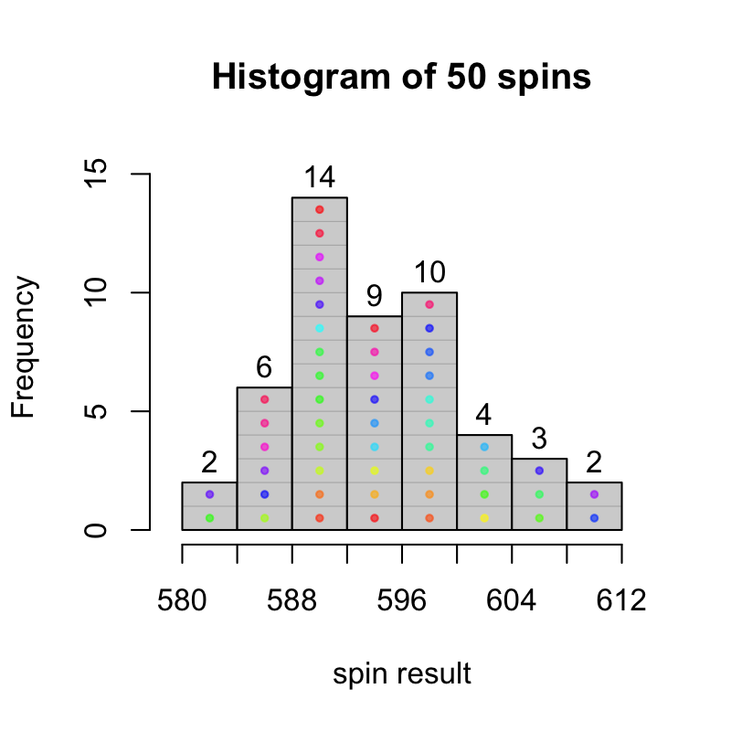

- How many spins were less than 596?
  - $\#(x<596) =$
- What proportion of spins were less than 596?
  - $\mathrm{proportion}(x<596) =$
- How many spins were more than 600?
  - $\#(x>600) =$
- What proportion of spins were more than 600?
  - $\mathrm{proportion}(x>600) =$
- How many spins were between 592 and 608?
  - $\#(592<x<608) =$
- What proportion of spins were between 592 and 608?
  - $\mathrm{proportion}(592<x<608) =$
- $\#(x<596) =$ 31
- $\mathrm{proportion}(x<596) = \frac{31}{50} =$ 0.62
- $\#(x>600) =$ 9
- $\mathrm{proportion}(x>600) = \frac{9}{50} =$ 0.18
- $\#(592<x<608) =$ 26
- $\mathrm{proportion}(592<x<608) = \frac{26}{50} =$ 0.52

You might find the following visualizations helpful.

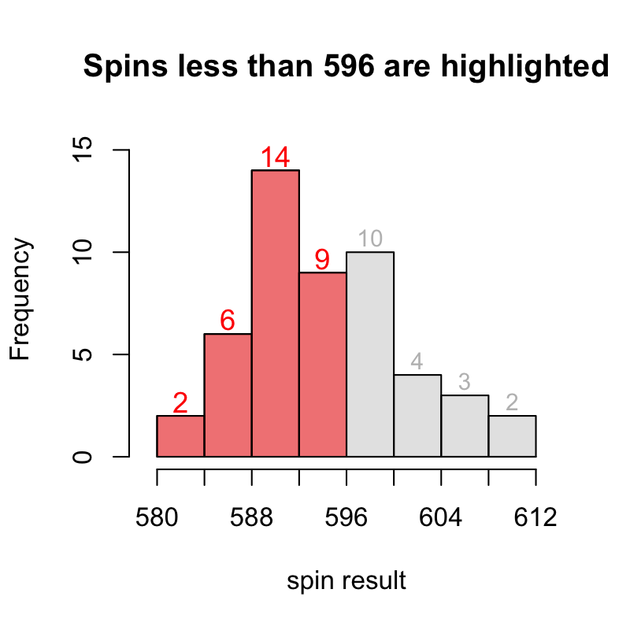

$$2+6+14+9=31$$

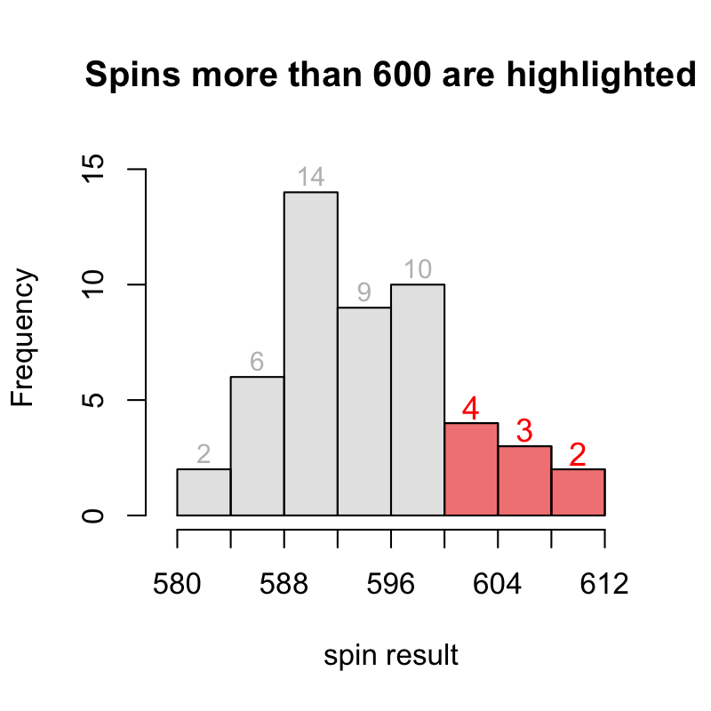

$$4+3+2=9$$

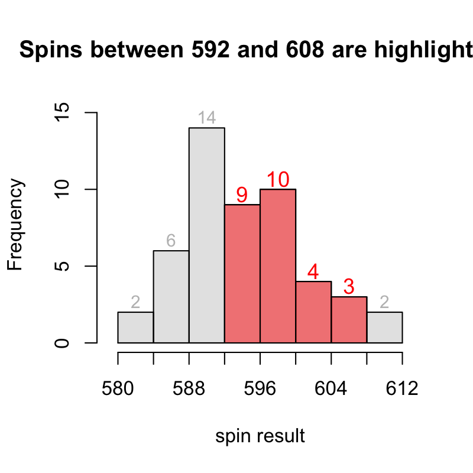

$$9+10+4+3=26$$

*S-ID.A: Summarize, represent, and interpret data on a single count or measurement variable. Use calculators, spreadsheets, and other technology as appropriate.*

A spinner was made to model a [continuous triangular distribution](https://en.wikipedia.org/wiki/Triangular_distribution). It was spun 50 times; those locations are marked.

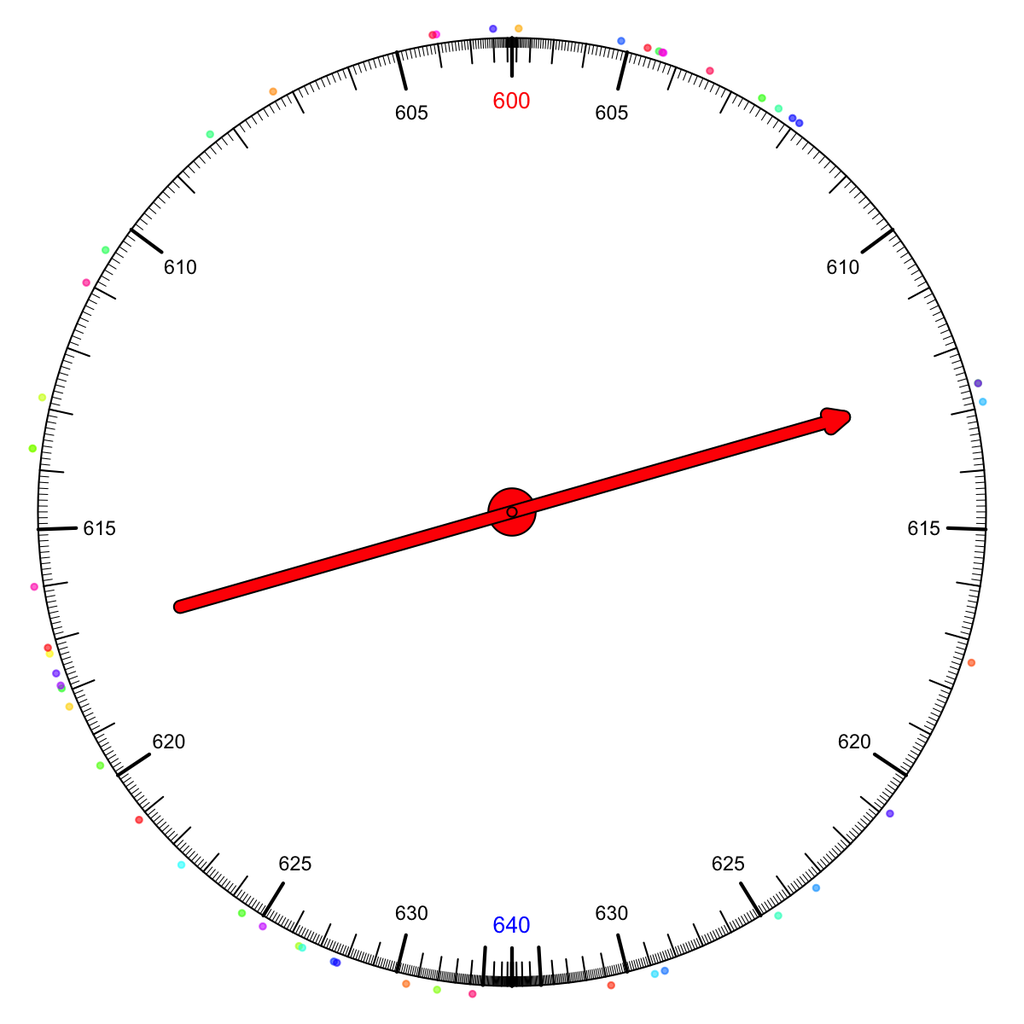

The name "triangular distribution" comes from the probability density curve.

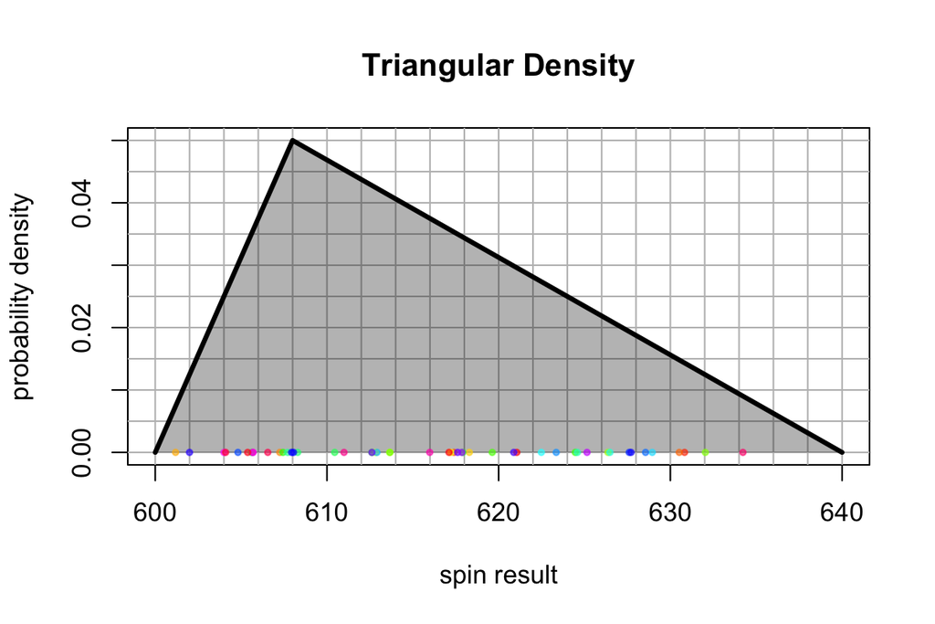

Notice that because the spinner is continuous, it generates data like 617.2771626 and 617.5281342. Of course, a human would probably round to the nearest tenth or so.

### Actual question

The 50 spins were used to generate a histogram.

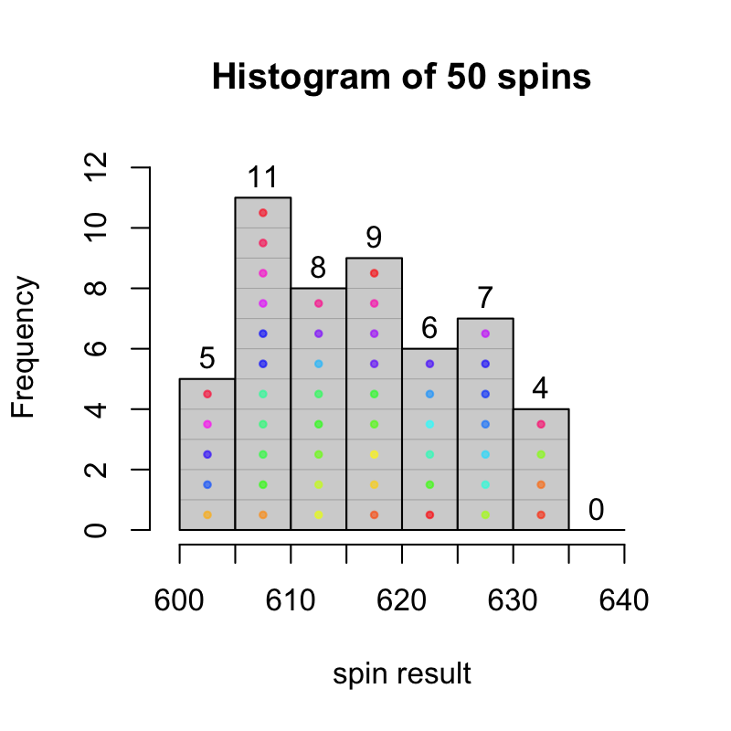

- How many spins were less than 615?
  - $\#(x<615) =$
- What proportion of spins were less than 615?
  - $\mathrm{proportion}(x<615) =$
- How many spins were more than 625?
  - $\#(x>625) =$
- What proportion of spins were more than 625?
  - $\mathrm{proportion}(x>625) =$
- How many spins were between 610 and 635?
  - $\#(610<x<635) =$
- What proportion of spins were between 610 and 635?
  - $\mathrm{proportion}(610<x<635) =$
- $\#(x<615) =$ 24
- $\mathrm{proportion}(x<615) = \frac{24}{50} =$ 0.48
- $\#(x>625) =$ 11
- $\mathrm{proportion}(x>625) = \frac{11}{50} =$ 0.22
- $\#(610<x<635) =$ 34
- $\mathrm{proportion}(610<x<635) = \frac{34}{50} =$ 0.68

You might find the following visualizations helpful.

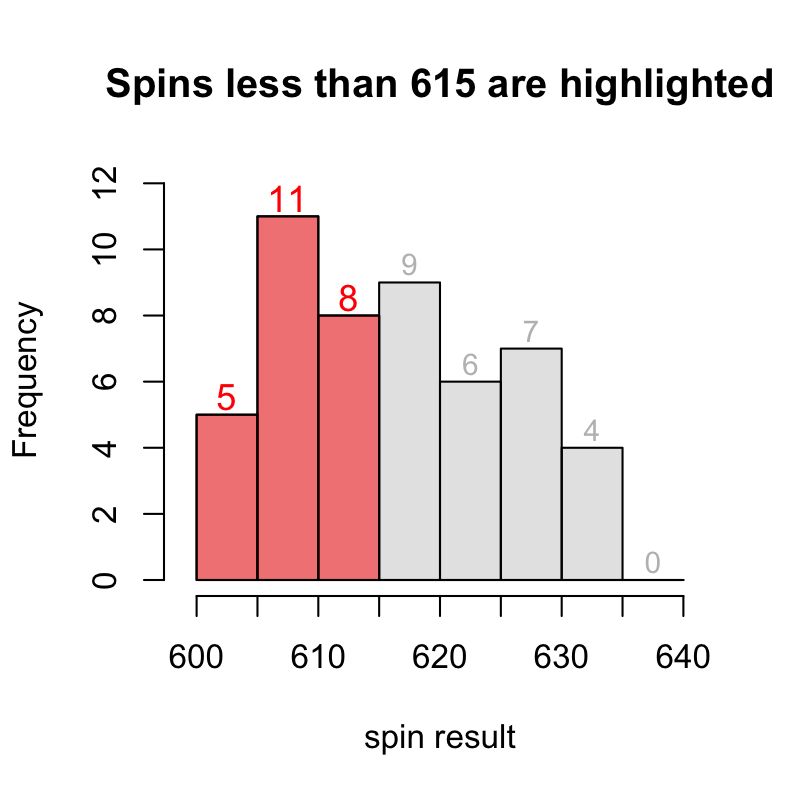

$$5+11+8=24$$

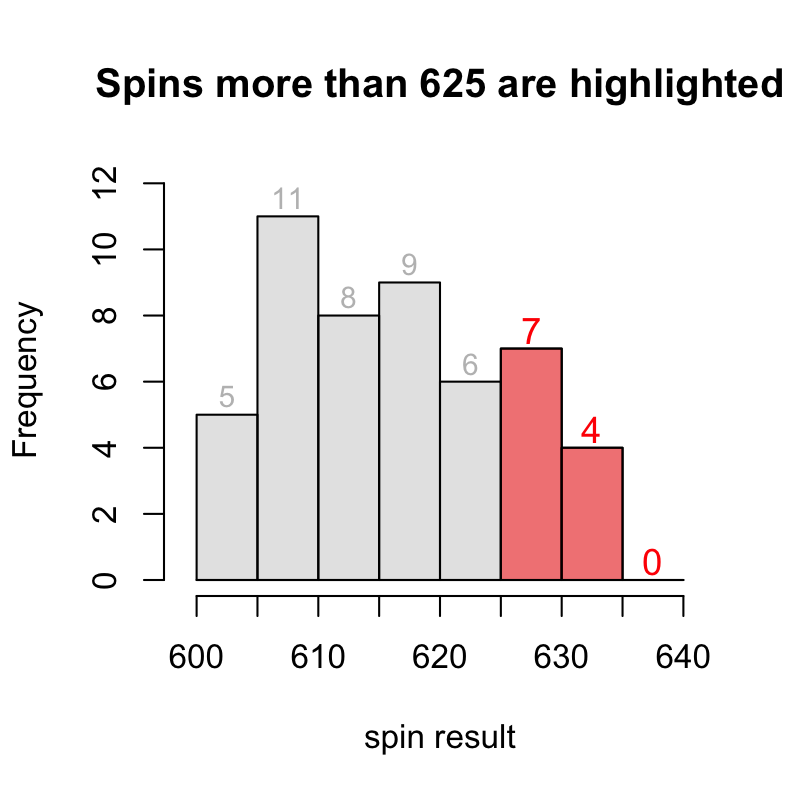

$$7+4+0=11$$

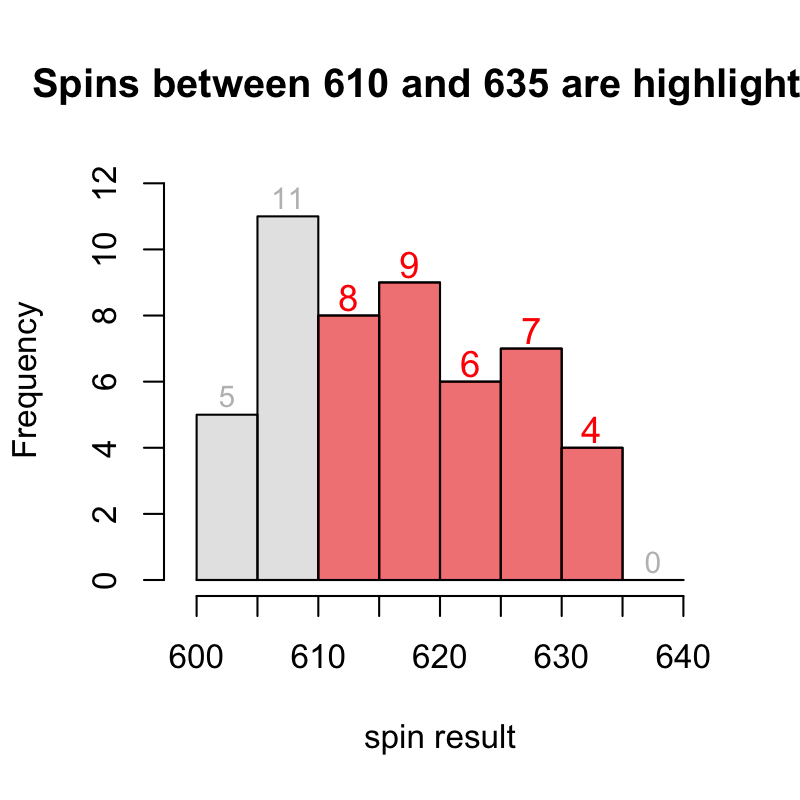

$$8+9+6+7+4=34$$

*S-ID.A: Summarize, represent, and interpret data on a single count or measurement variable. Use calculators, spreadsheets, and other technology as appropriate.*

A spinner was made to model a [continuous triangular distribution](https://en.wikipedia.org/wiki/Triangular_distribution). It was spun 50 times; those locations are marked.

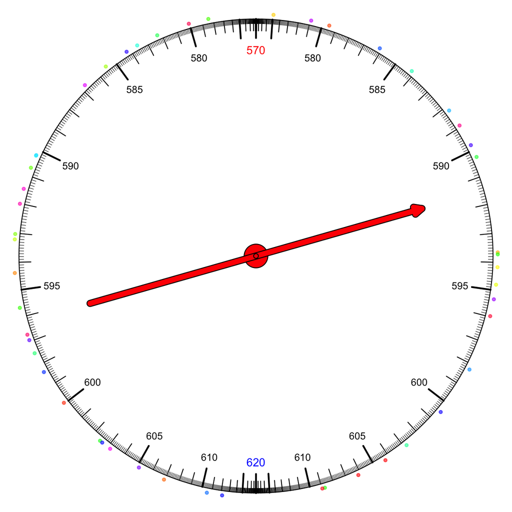

The name "triangular distribution" comes from the probability density curve.

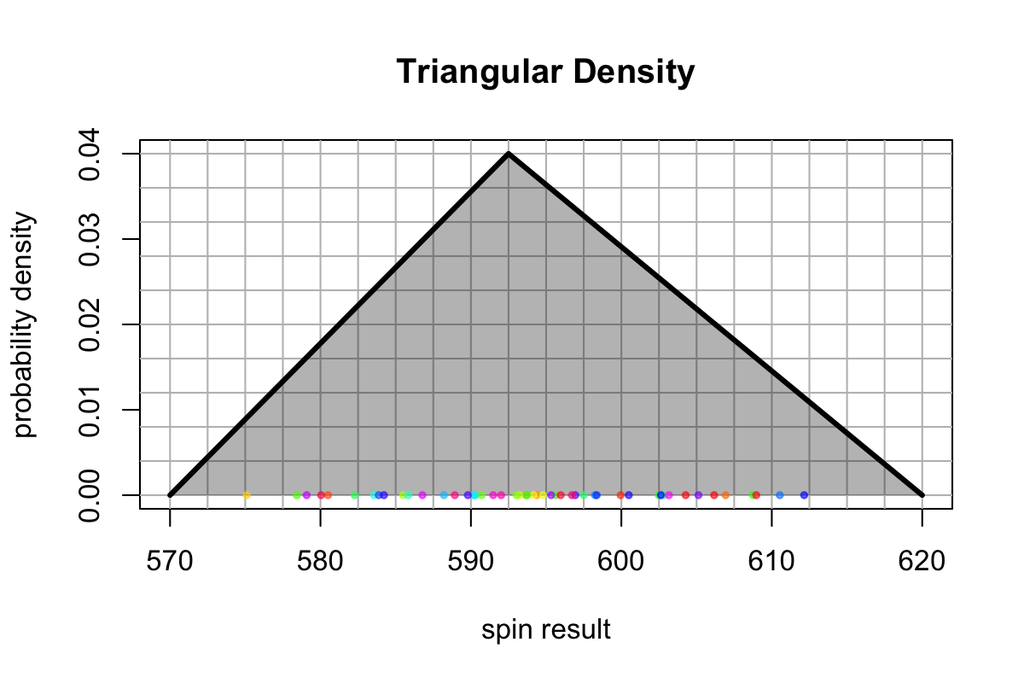

Notice that because the spinner is continuous, it generates data like 584.3703714 and 587.7008889. Of course, a human would probably round to the nearest tenth or so.

### Actual question

The 50 spins were used to generate a histogram.

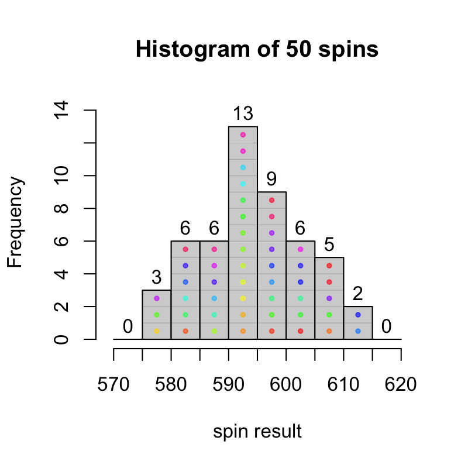

- How many spins were less than 585?
  - $\#(x<585) =$
- What proportion of spins were less than 585?
  - $\mathrm{proportion}(x<585) =$
- How many spins were more than 605?
  - $\#(x>605) =$
- What proportion of spins were more than 605?
  - $\mathrm{proportion}(x>605) =$
- How many spins were between 590 and 610?
  - $\#(590<x<610) =$
- What proportion of spins were between 590 and 610?
  - $\mathrm{proportion}(590<x<610) =$
- $\#(x<585) =$ 9
- $\mathrm{proportion}(x<585) = \frac{9}{50} =$ 0.18
- $\#(x>605) =$ 7
- $\mathrm{proportion}(x>605) = \frac{7}{50} =$ 0.14
- $\#(590<x<610) =$ 33
- $\mathrm{proportion}(590<x<610) = \frac{33}{50} =$ 0.66

You might find the following visualizations helpful.

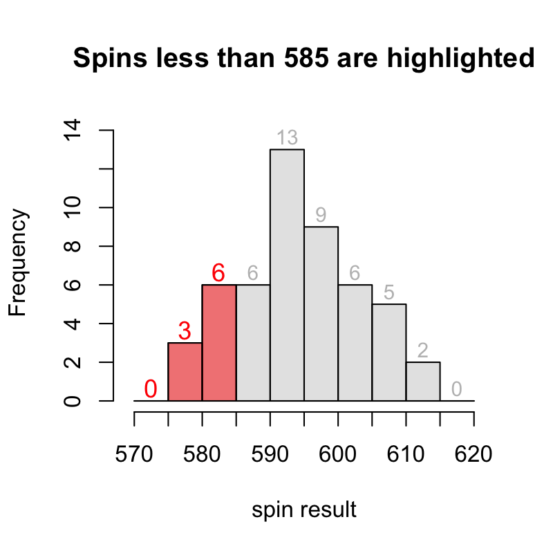

$$0+3+6=9$$

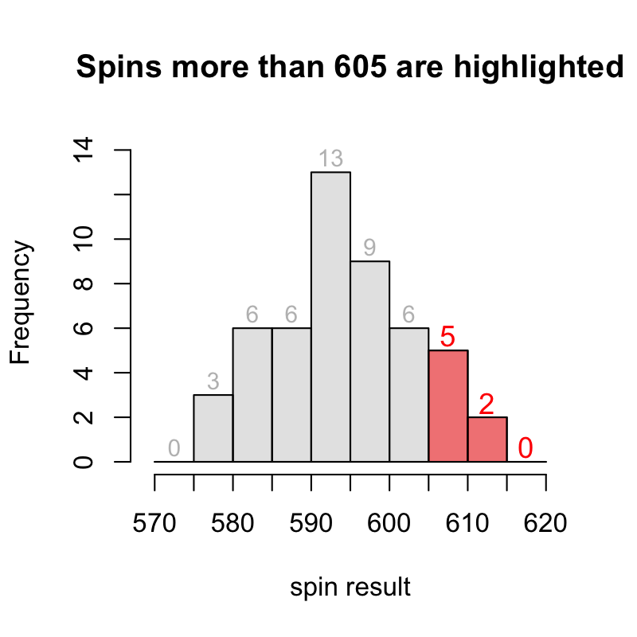

$$5+2+0=7$$

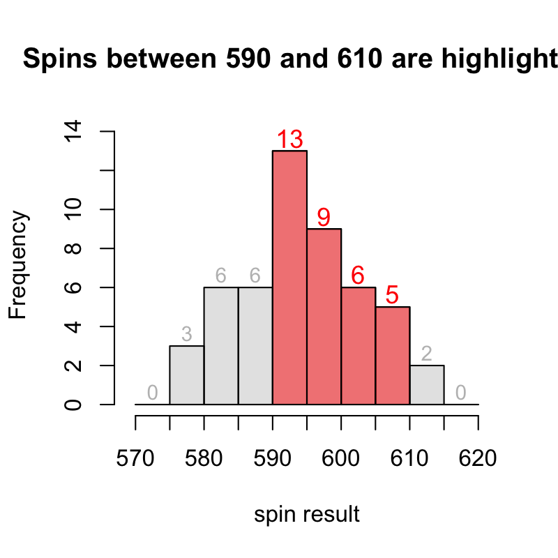

$$13+9+6+5=33$$

*S-ID.A: Summarize, represent, and interpret data on a single count or measurement variable. Use calculators, spreadsheets, and other technology as appropriate.*

A spinner was made to model a [continuous triangular distribution](https://en.wikipedia.org/wiki/Triangular_distribution). It was spun 50 times; those locations are marked.

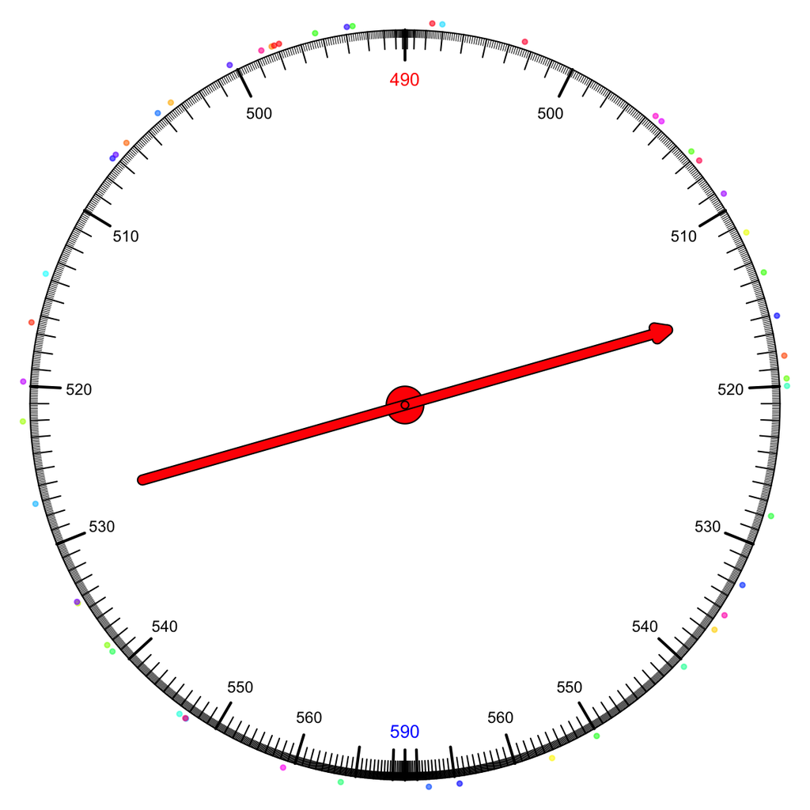

The name "triangular distribution" comes from the probability density curve.

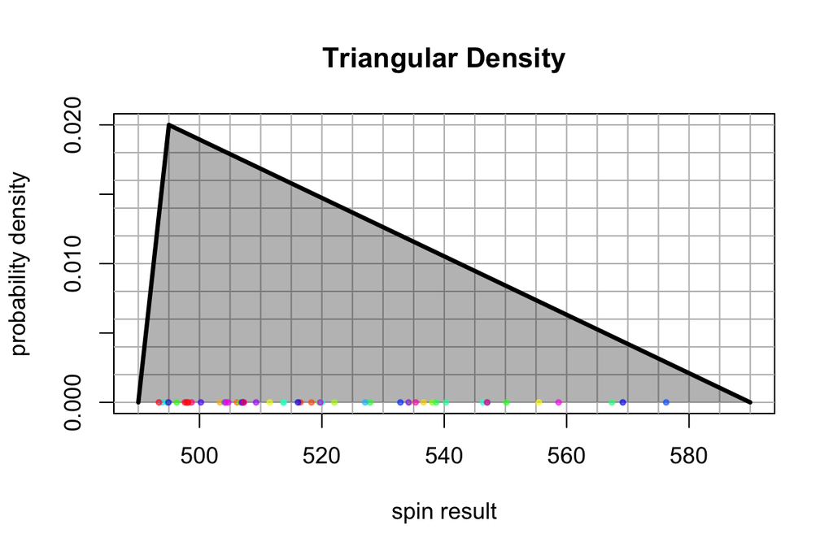

Notice that because the spinner is continuous, it generates data like 506.4719307 and 504.8569149. Of course, a human would probably round to the nearest tenth or so.

### Actual question

The 50 spins were used to generate a histogram.

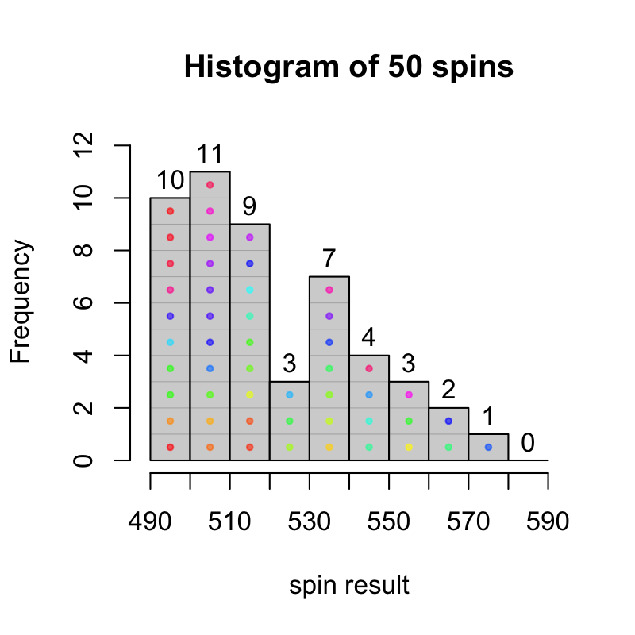

- How many spins were less than 530?
  - $\#(x<530) =$
- What proportion of spins were less than 530?
  - $\mathrm{proportion}(x<530) =$
- How many spins were more than 510?
  - $\#(x>510) =$
- What proportion of spins were more than 510?
  - $\mathrm{proportion}(x>510) =$
- How many spins were between 500 and 550?
  - $\#(500<x<550) =$
- What proportion of spins were between 500 and 550?
  - $\mathrm{proportion}(500<x<550) =$
- $\#(x<530) =$ 33
- $\mathrm{proportion}(x<530) = \frac{33}{50} =$ 0.66
- $\#(x>510) =$ 29
- $\mathrm{proportion}(x>510) = \frac{29}{50} =$ 0.58
- $\#(500<x<550) =$ 34
- $\mathrm{proportion}(500<x<550) = \frac{34}{50} =$ 0.68

You might find the following visualizations helpful.

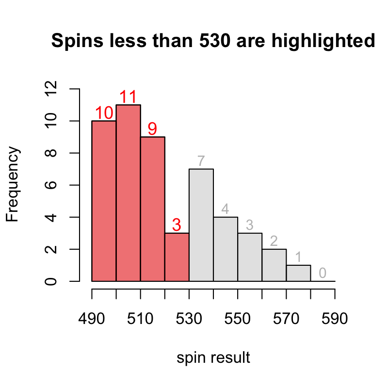

$$10+11+9+3=33$$

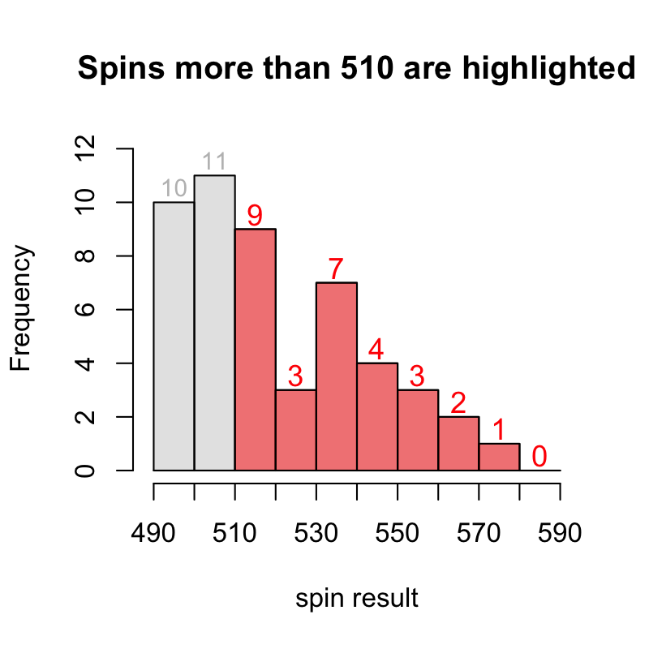

$$9+3+7+4+3+2+1+0=29$$

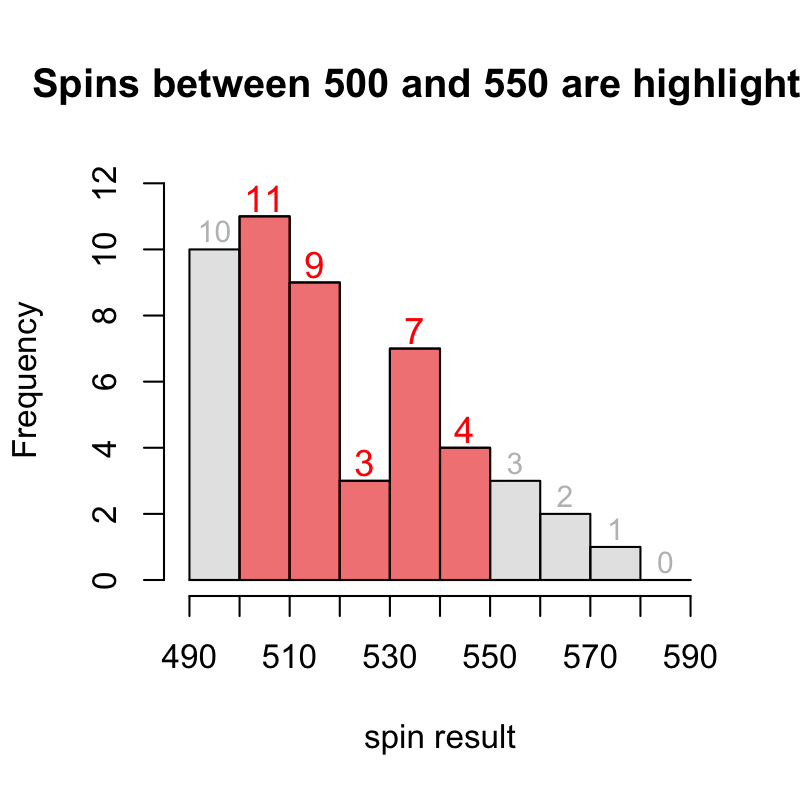

$$11+9+3+7+4=34$$

*S-ID.A: Summarize, represent, and interpret data on a single count or measurement variable. Use calculators, spreadsheets, and other technology as appropriate.*

A spinner was made to model a [continuous triangular distribution](https://en.wikipedia.org/wiki/Triangular_distribution). It was spun 50 times; those locations are marked.

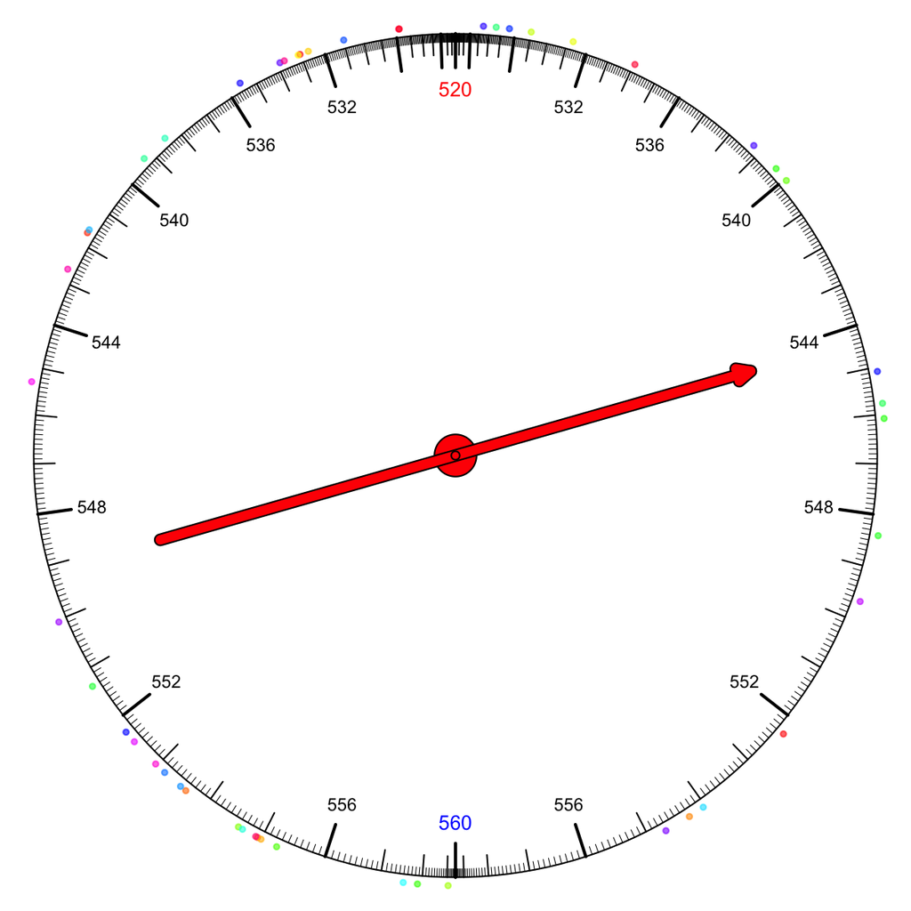

The name "triangular distribution" comes from the probability density curve.

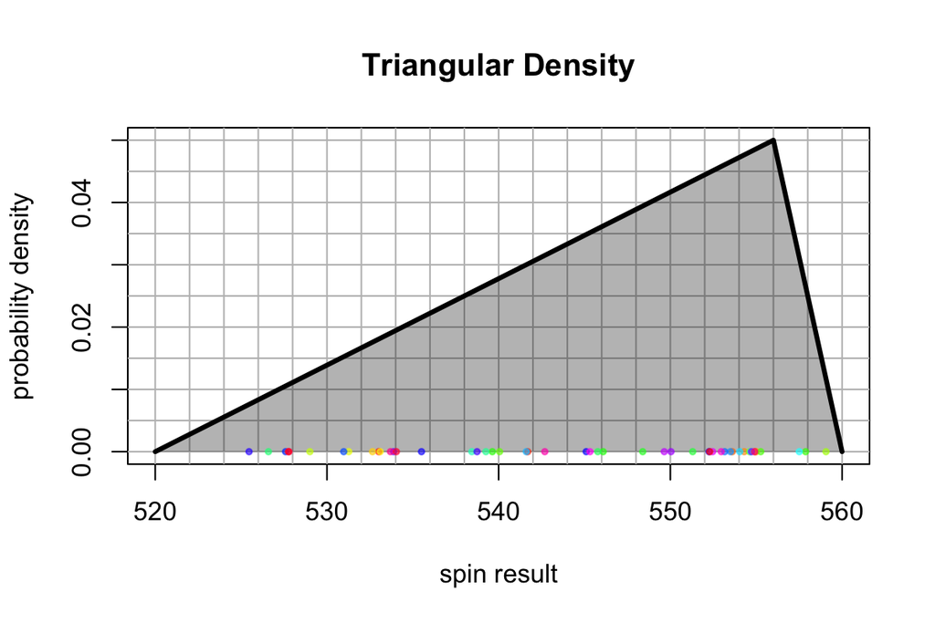

Notice that because the spinner is continuous, it generates data like 546.4571757 and 532.0145195. Of course, a human would probably round to the nearest tenth or so.

### Actual question

The 50 spins were used to generate a histogram.

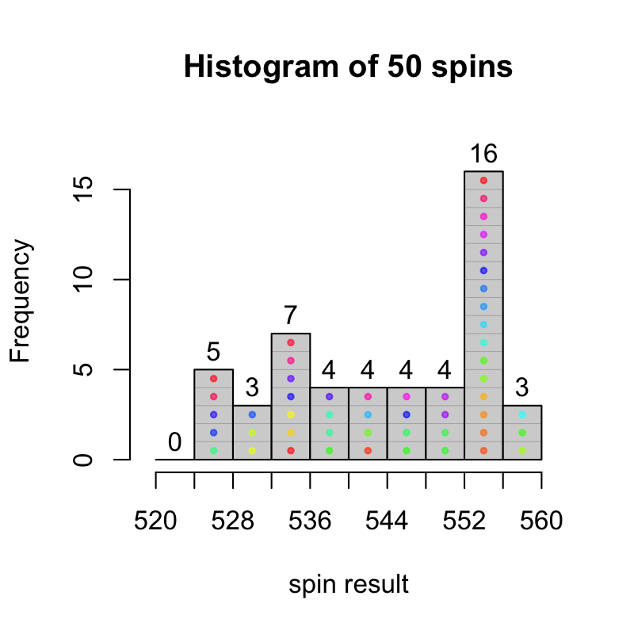

- How many spins were less than 548?
  - $\#(x<548) =$
- What proportion of spins were less than 548?
  - $\mathrm{proportion}(x<548) =$
- How many spins were more than 540?
  - $\#(x>540) =$
- What proportion of spins were more than 540?
  - $\mathrm{proportion}(x>540) =$
- How many spins were between 528 and 552?
  - $\#(528<x<552) =$
- What proportion of spins were between 528 and 552?
  - $\mathrm{proportion}(528<x<552) =$
- $\#(x<548) =$ 27
- $\mathrm{proportion}(x<548) = \frac{27}{50} =$ 0.54
- $\#(x>540) =$ 31
- $\mathrm{proportion}(x>540) = \frac{31}{50} =$ 0.62
- $\#(528<x<552) =$ 26
- $\mathrm{proportion}(528<x<552) = \frac{26}{50} =$ 0.52

You might find the following visualizations helpful.

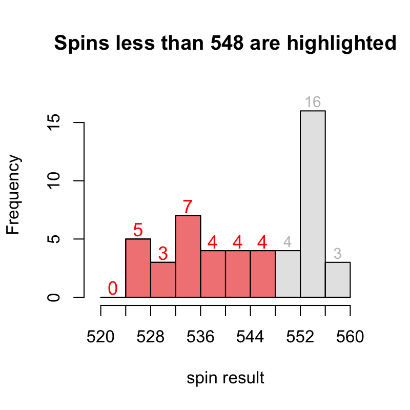

$$0+5+3+7+4+4+4=27$$

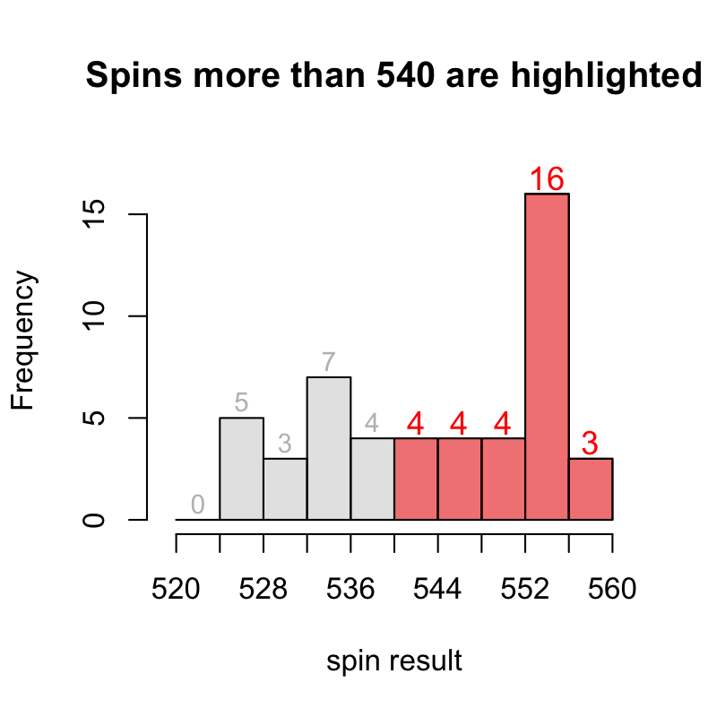

$$4+4+4+16+3=31$$

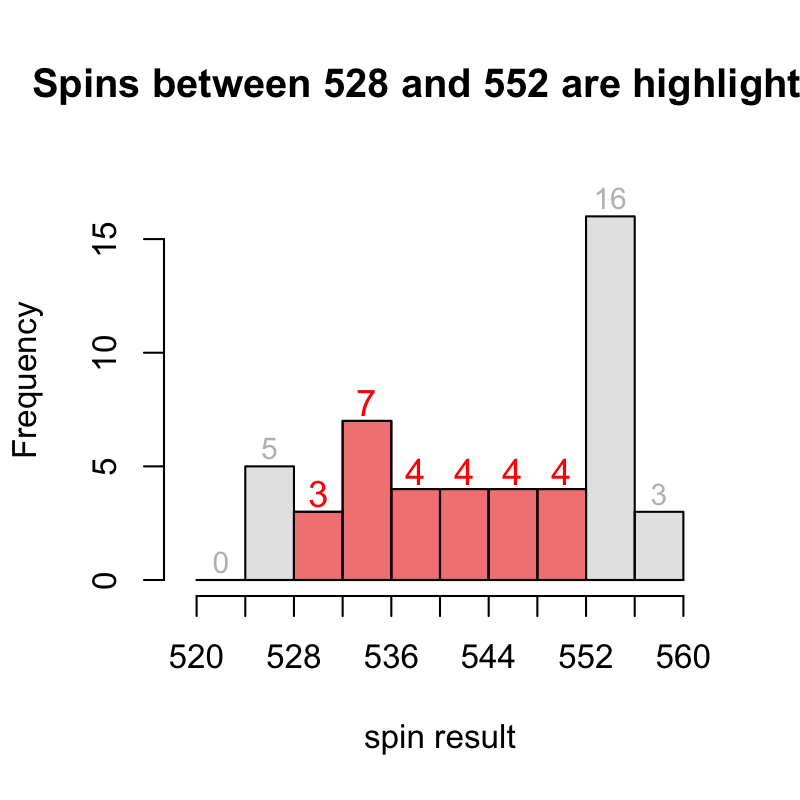

$$3+7+4+4+4+4=26$$

*S-ID.A: Summarize, represent, and interpret data on a single count or measurement variable. Use calculators, spreadsheets, and other technology as appropriate.*

A spinner was made to model a [continuous triangular distribution](https://en.wikipedia.org/wiki/Triangular_distribution). It was spun 50 times; those locations are marked.

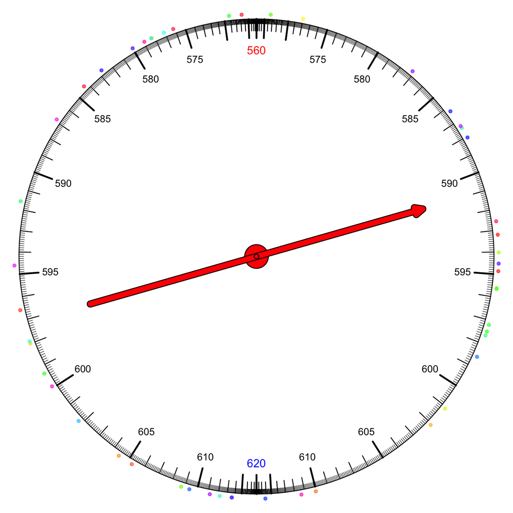

The name "triangular distribution" comes from the probability density curve.

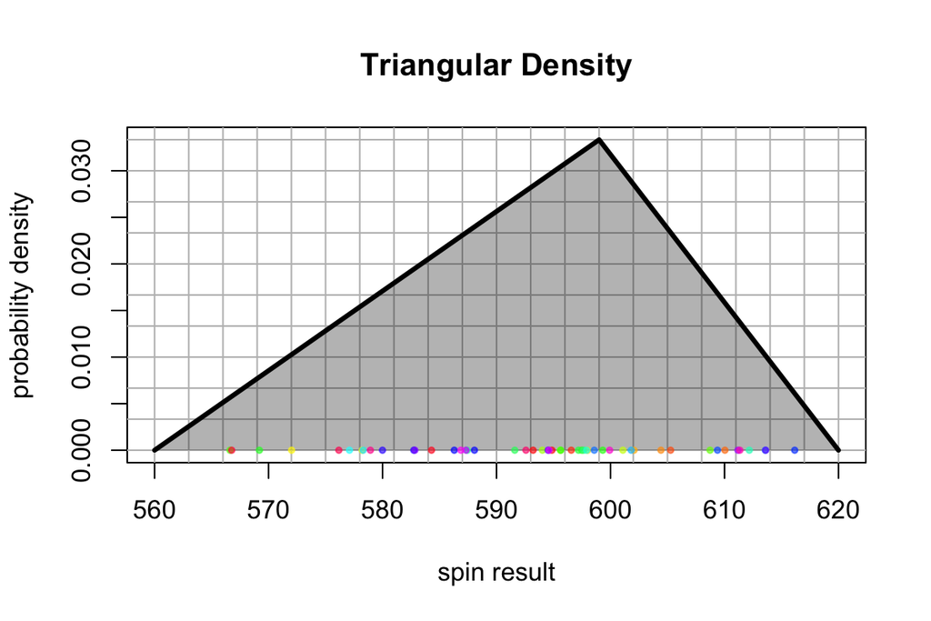

Notice that because the spinner is continuous, it generates data like 606.1576928 and 604.8923129. Of course, a human would probably round to the nearest tenth or so.

### Actual question

The 50 spins were used to generate a histogram.

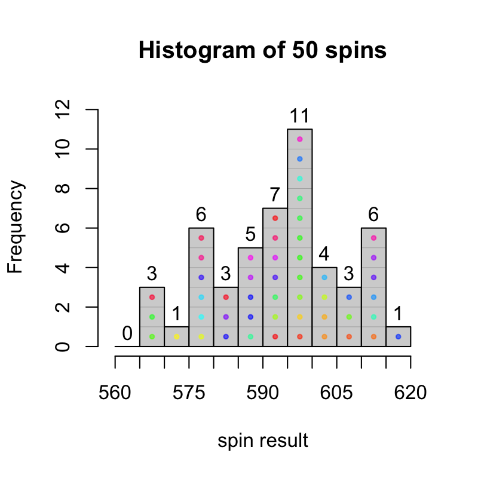

- How many spins were less than 585?
  - $\#(x<585) =$
- What proportion of spins were less than 585?
  - $\mathrm{proportion}(x<585) =$
- How many spins were more than 605?
  - $\#(x>605) =$
- What proportion of spins were more than 605?
  - $\mathrm{proportion}(x>605) =$
- How many spins were between 580 and 615?
  - $\#(580<x<615) =$
- What proportion of spins were between 580 and 615?
  - $\mathrm{proportion}(580<x<615) =$
- $\#(x<585) =$ 13
- $\mathrm{proportion}(x<585) = \frac{13}{50} =$ 0.26
- $\#(x>605) =$ 10
- $\mathrm{proportion}(x>605) = \frac{10}{50} =$ 0.2
- $\#(580<x<615) =$ 39
- $\mathrm{proportion}(580<x<615) = \frac{39}{50} =$ 0.78

You might find the following visualizations helpful.

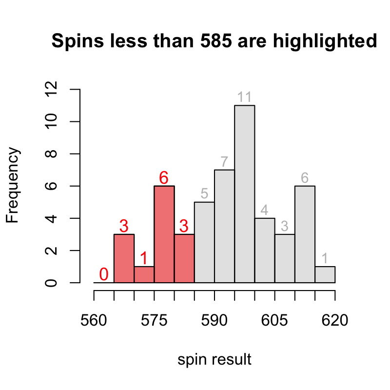

$$0+3+1+6+3=13$$

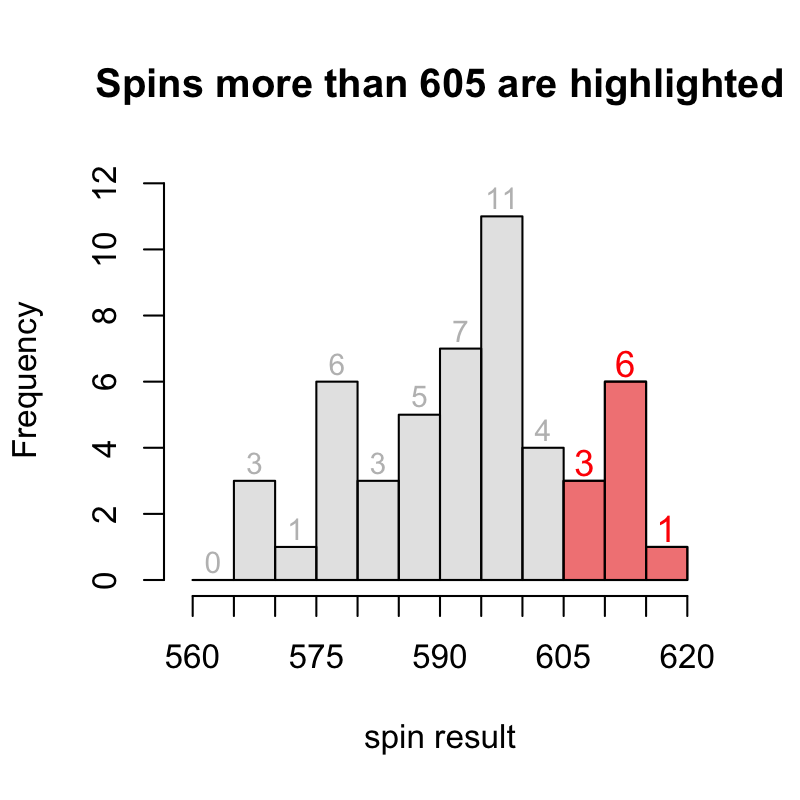

$$3+6+1=10$$

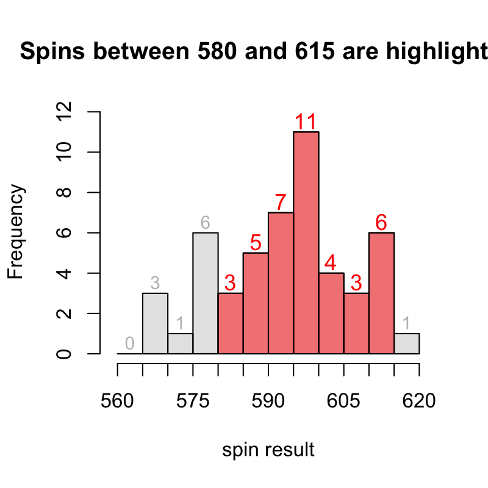

$$3+5+7+11+4+3+6=39$$

*S-ID.A: Summarize, represent, and interpret data on a single count or measurement variable. Use calculators, spreadsheets, and other technology as appropriate.*

A spinner was made to model a [continuous triangular distribution](https://en.wikipedia.org/wiki/Triangular_distribution). It was spun 50 times; those locations are marked.

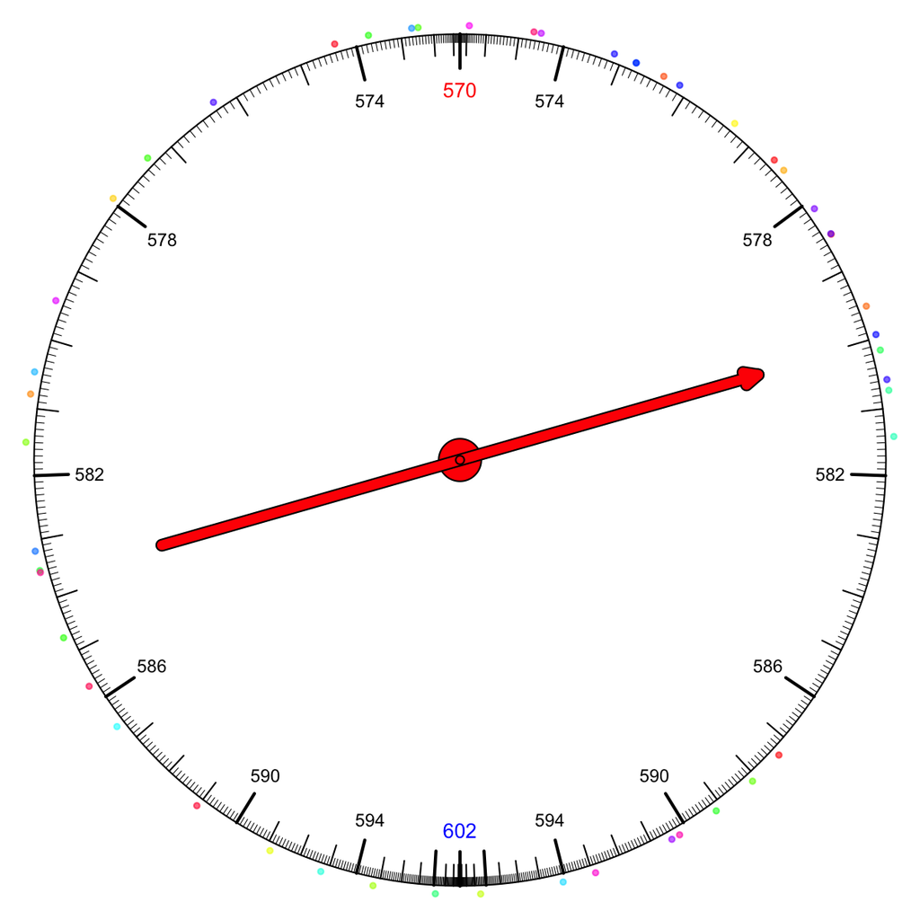

The name "triangular distribution" comes from the probability density curve.

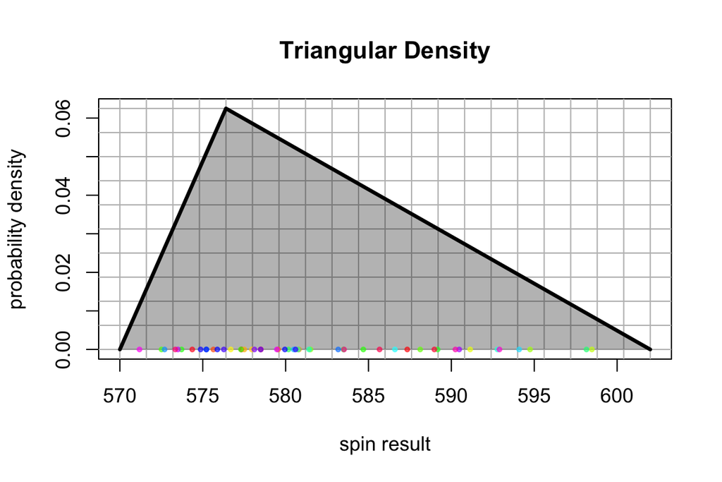

Notice that because the spinner is continuous, it generates data like 578.4609515 and 577.1901117. Of course, a human would probably round to the nearest tenth or so.

### Actual question

The 50 spins were used to generate a histogram.

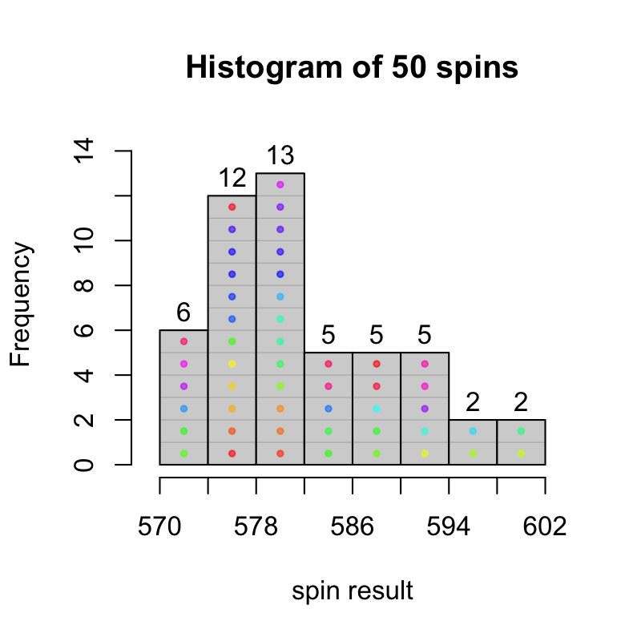

- How many spins were less than 582?
  - $\#(x<582) =$
- What proportion of spins were less than 582?
  - $\mathrm{proportion}(x<582) =$
- How many spins were more than 586?
  - $\#(x>586) =$
- What proportion of spins were more than 586?
  - $\mathrm{proportion}(x>586) =$
- How many spins were between 578 and 594?
  - $\#(578<x<594) =$
- What proportion of spins were between 578 and 594?
  - $\mathrm{proportion}(578<x<594) =$
- $\#(x<582) =$ 31
- $\mathrm{proportion}(x<582) = \frac{31}{50} =$ 0.62
- $\#(x>586) =$ 14
- $\mathrm{proportion}(x>586) = \frac{14}{50} =$ 0.28
- $\#(578<x<594) =$ 28
- $\mathrm{proportion}(578<x<594) = \frac{28}{50} =$ 0.56

You might find the following visualizations helpful.

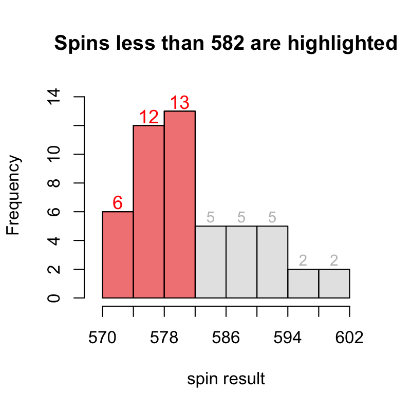

$$6+12+13=31$$

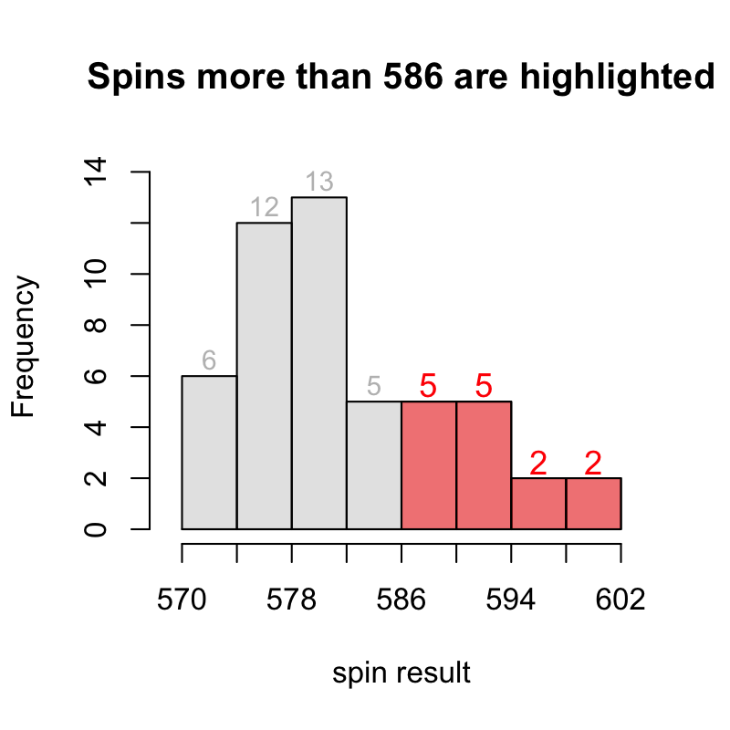

$$5+5+2+2=14$$

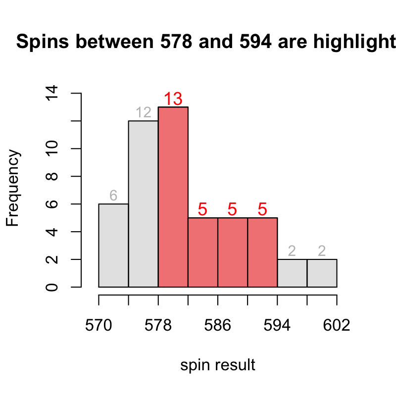

$$13+5+5+5=28$$

*S-ID.A: Summarize, represent, and interpret data on a single count or measurement variable. Use calculators, spreadsheets, and other technology as appropriate.*

A spinner was made to model a [continuous triangular distribution](https://en.wikipedia.org/wiki/Triangular_distribution). It was spun 50 times; those locations are marked.

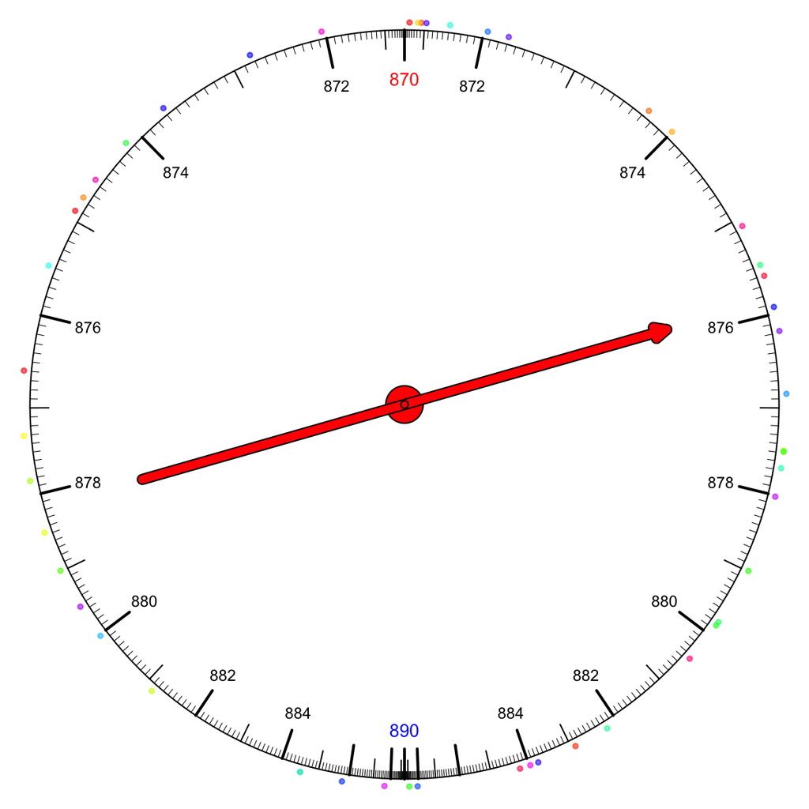

The name "triangular distribution" comes from the probability density curve.

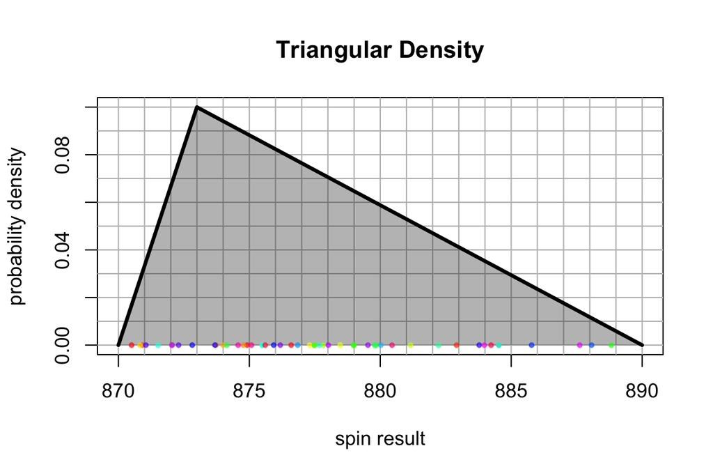

Notice that because the spinner is continuous, it generates data like 877.8046554 and 873.6405587. Of course, a human would probably round to the nearest tenth or so.

### Actual question

The 50 spins were used to generate a histogram.

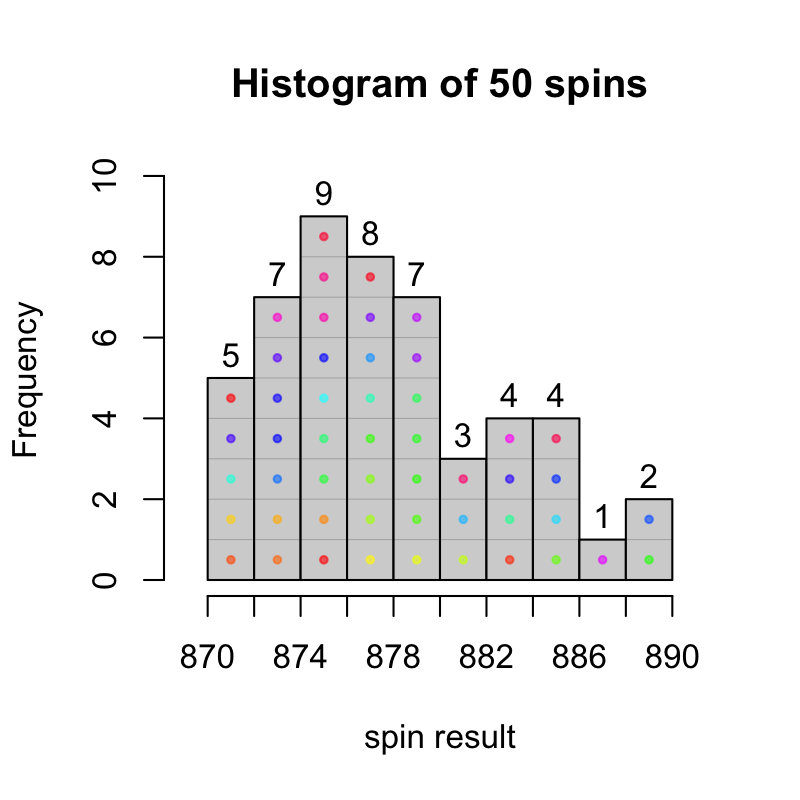

- How many spins were less than 880?
  - $\#(x<880) =$
- What proportion of spins were less than 880?
  - $\mathrm{proportion}(x<880) =$
- How many spins were more than 874?
  - $\#(x>874) =$
- What proportion of spins were more than 874?
  - $\mathrm{proportion}(x>874) =$
- How many spins were between 876 and 884?
  - $\#(876<x<884) =$
- What proportion of spins were between 876 and 884?
  - $\mathrm{proportion}(876<x<884) =$
- $\#(x<880) =$ 36
- $\mathrm{proportion}(x<880) = \frac{36}{50} =$ 0.72
- $\#(x>874) =$ 38
- $\mathrm{proportion}(x>874) = \frac{38}{50} =$ 0.76
- $\#(876<x<884) =$ 22
- $\mathrm{proportion}(876<x<884) = \frac{22}{50} =$ 0.44

You might find the following visualizations helpful.

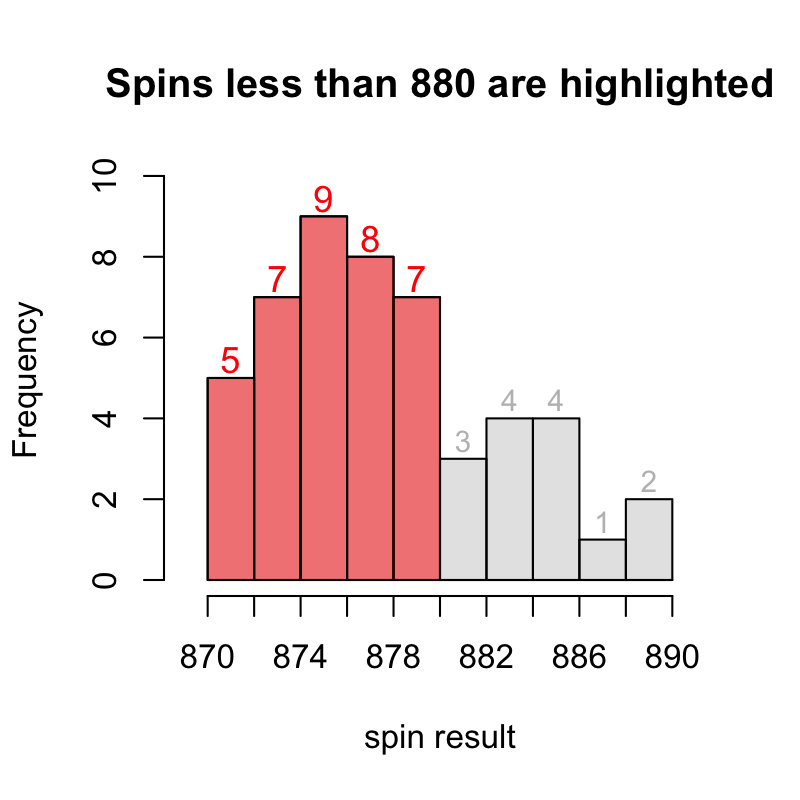

$$5+7+9+8+7=36$$

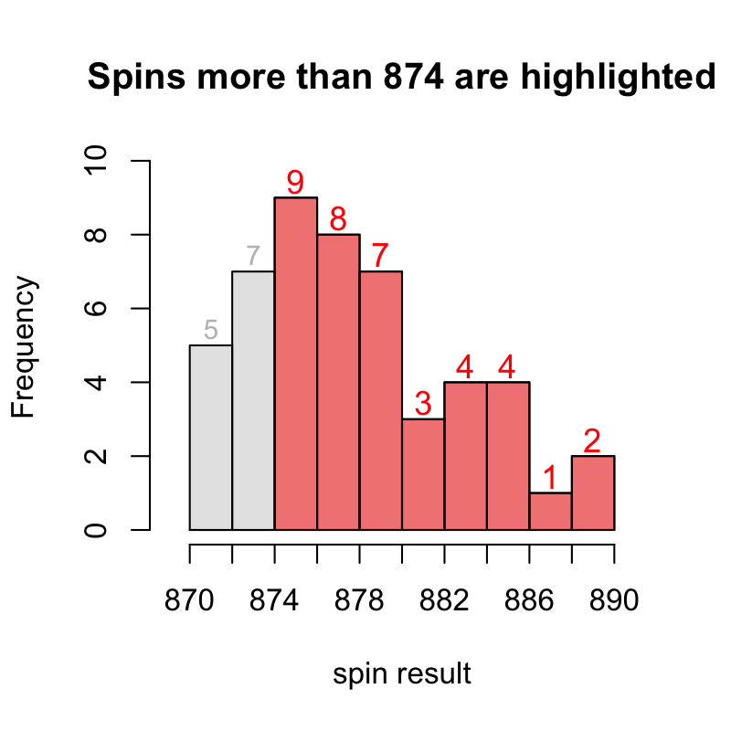

$$9+8+7+3+4+4+1+2=38$$

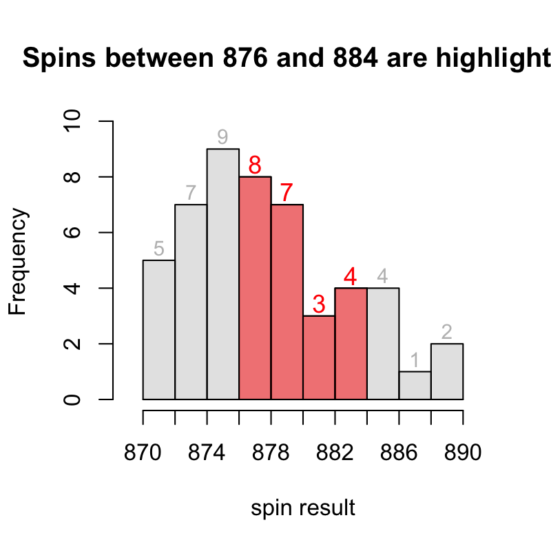

$$8+7+3+4=22$$

*S-ID.A: Summarize, represent, and interpret data on a single count or measurement variable. Use calculators, spreadsheets, and other technology as appropriate.*

A spinner was made to model a [continuous triangular distribution](https://en.wikipedia.org/wiki/Triangular_distribution). It was spun 50 times; those locations are marked.

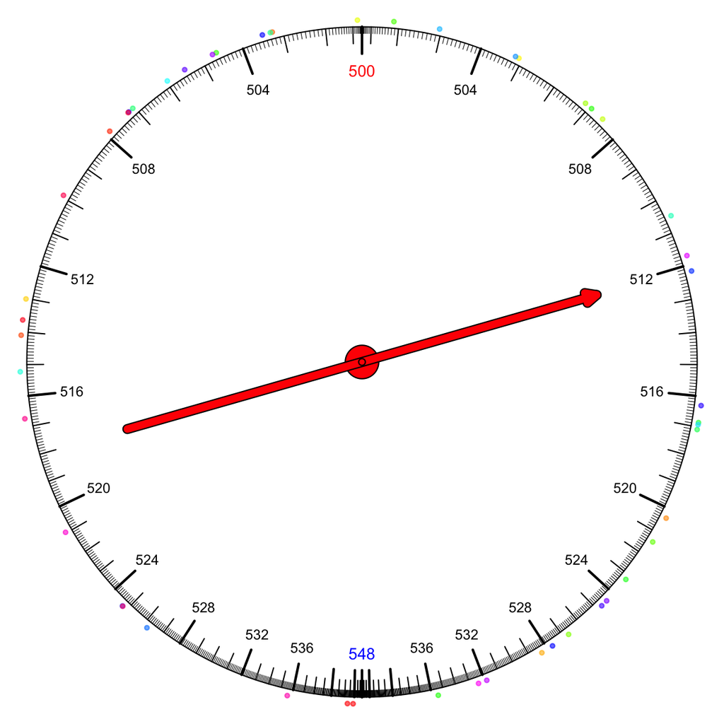

The name "triangular distribution" comes from the probability density curve.

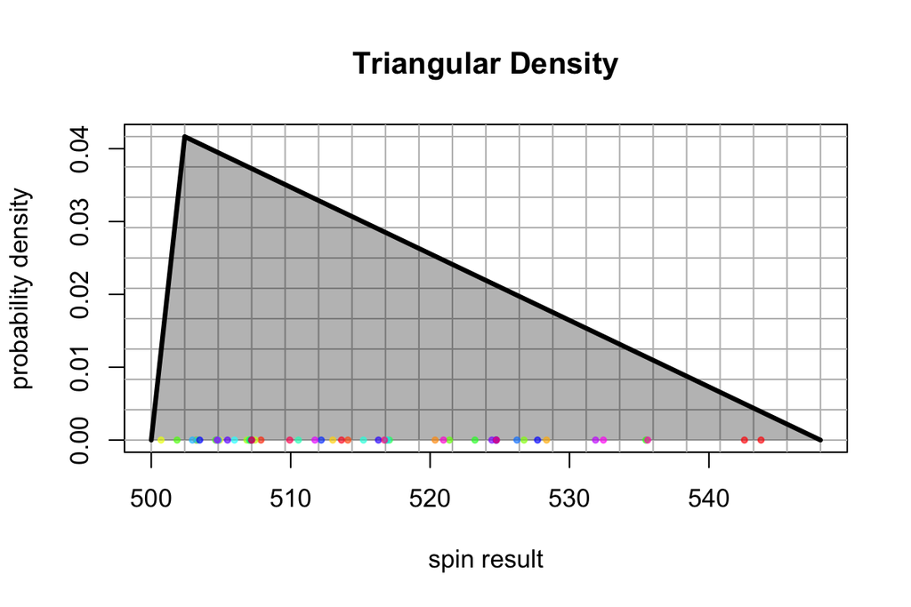

Notice that because the spinner is continuous, it generates data like 506.8176686 and 513.9600014. Of course, a human would probably round to the nearest tenth or so.

### Actual question

The 50 spins were used to generate a histogram.

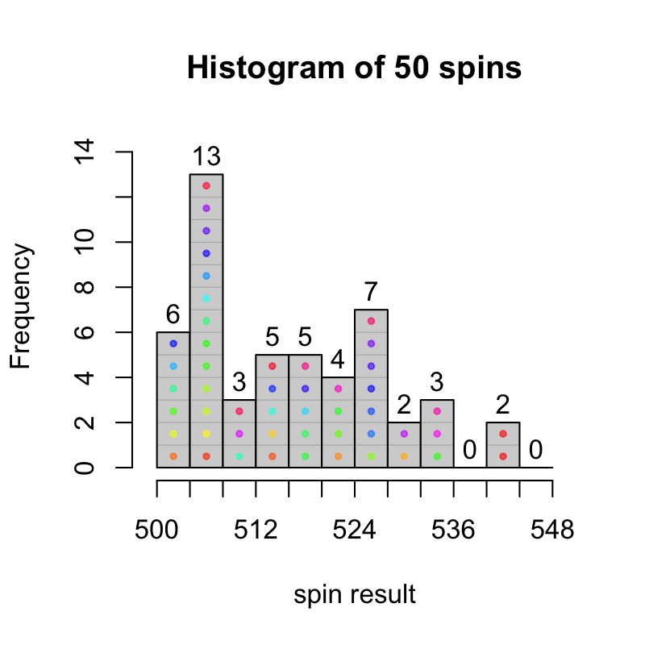

- How many spins were less than 520?
  - $\#(x<520) =$
- What proportion of spins were less than 520?
  - $\mathrm{proportion}(x<520) =$
- How many spins were more than 524?
  - $\#(x>524) =$
- What proportion of spins were more than 524?
  - $\mathrm{proportion}(x>524) =$
- How many spins were between 512 and 544?
  - $\#(512<x<544) =$
- What proportion of spins were between 512 and 544?
  - $\mathrm{proportion}(512<x<544) =$
- $\#(x<520) =$ 32
- $\mathrm{proportion}(x<520) = \frac{32}{50} =$ 0.64
- $\#(x>524) =$ 14
- $\mathrm{proportion}(x>524) = \frac{14}{50} =$ 0.28
- $\#(512<x<544) =$ 28
- $\mathrm{proportion}(512<x<544) = \frac{28}{50} =$ 0.56

You might find the following visualizations helpful.

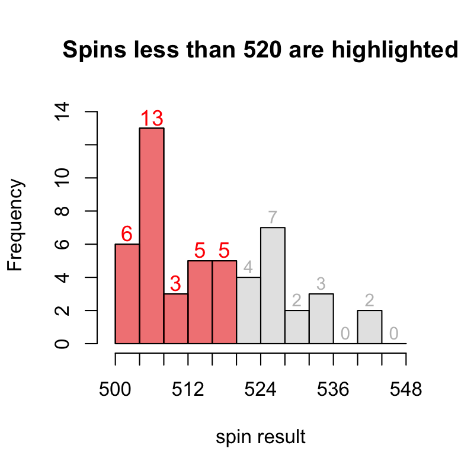

$$6+13+3+5+5=32$$

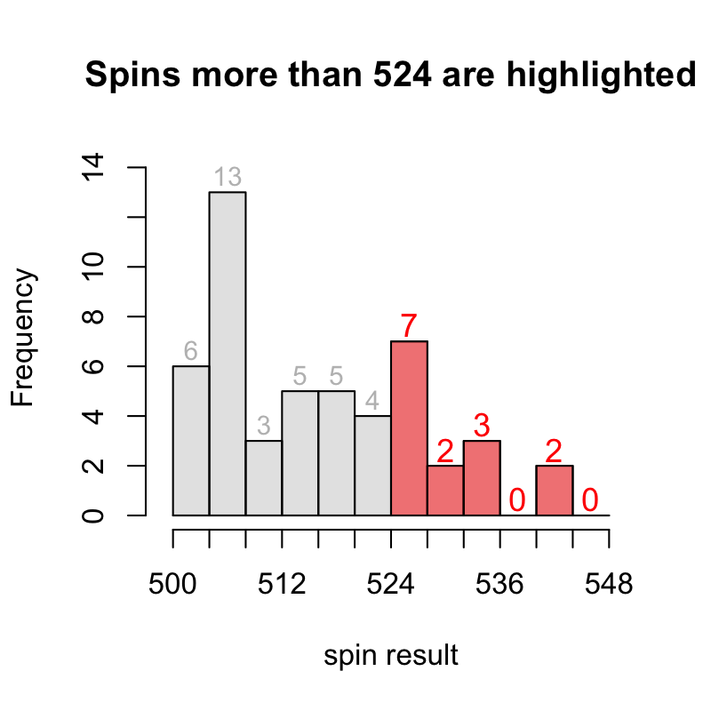

$$7+2+3+0+2+0=14$$

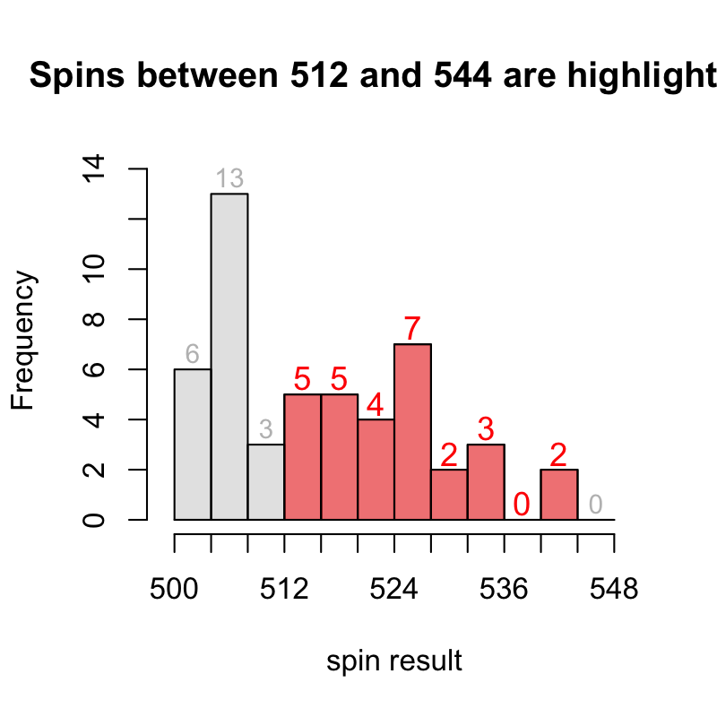

$$5+5+4+7+2+3+0+2=28$$

Jason drew two overlapping rectangles on a 10x10 grid.

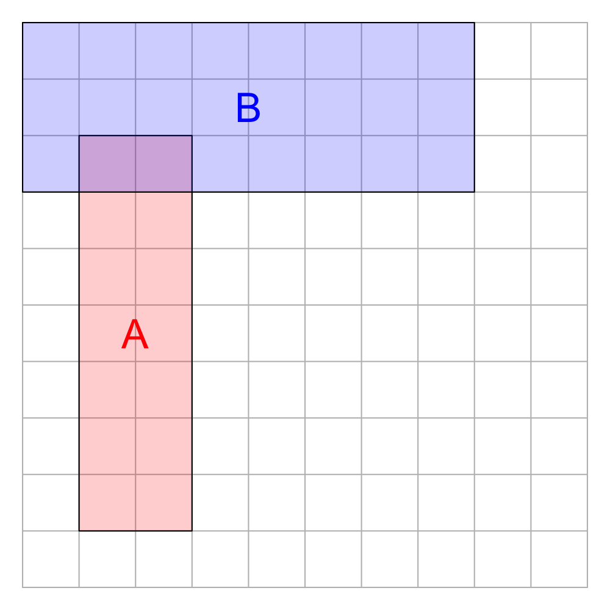

Let's call the red rectangle A and the blue rectangle B. Find the following areas:

- Area covered by A = squares
- Area covered by B = squares
- Area covered by the intersection of A and B = squares
- Area covered by the union of A and B = squares
- Area covered by ONLY A (and not B) = squares
- Area covered by ONLY B (and not A) = squares
- Area not covered (neither A nor B) = squares
- Area covered by A = 14
- Area covered by B = 24
- Area covered by the intersection of A and B = 2
- Area covered by the union of A and B = 36
- Area covered by ONLY A (and not B) = 12
- Area covered by ONLY B (and not A) = 22
- Area not covered (neither A nor B) = 64

Jason drew two overlapping rectangles on a 10x10 grid.

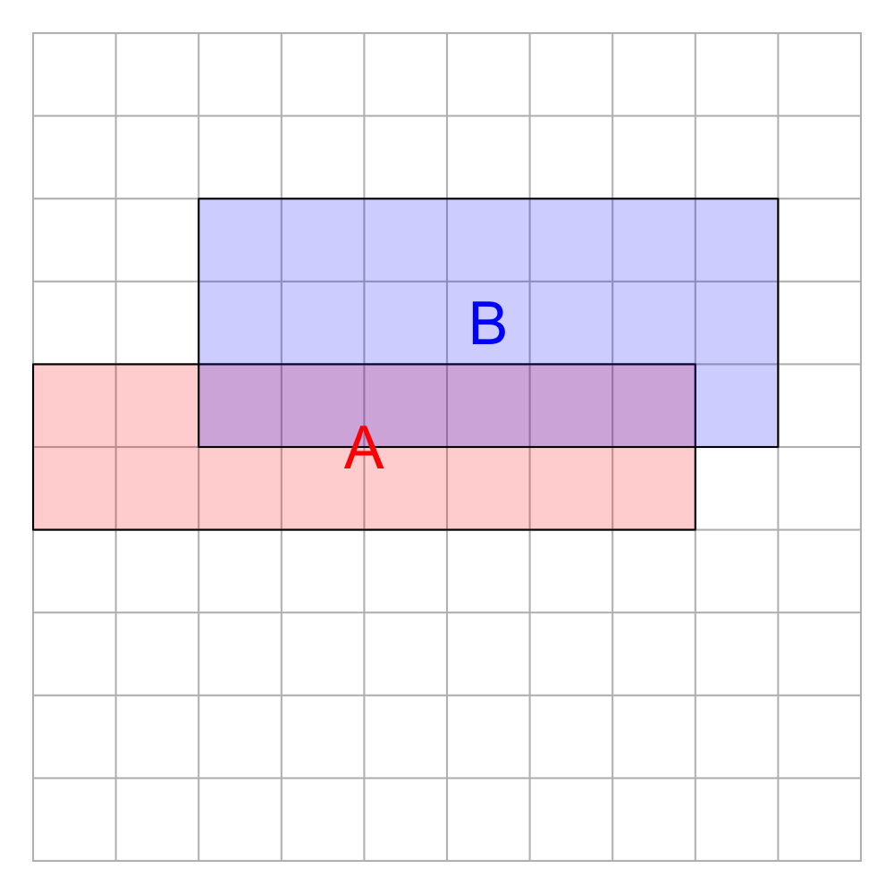

Let's call the red rectangle A and the blue rectangle B. Find the following areas:

- Area covered by A = squares
- Area covered by B = squares
- Area covered by the intersection of A and B = squares
- Area covered by the union of A and B = squares
- Area covered by ONLY A (and not B) = squares
- Area covered by ONLY B (and not A) = squares
- Area not covered (neither A nor B) = squares
- Area covered by A = 16
- Area covered by B = 21
- Area covered by the intersection of A and B = 6
- Area covered by the union of A and B = 31
- Area covered by ONLY A (and not B) = 10
- Area covered by ONLY B (and not A) = 15
- Area not covered (neither A nor B) = 69

Jason drew two overlapping rectangles on a 10x10 grid.

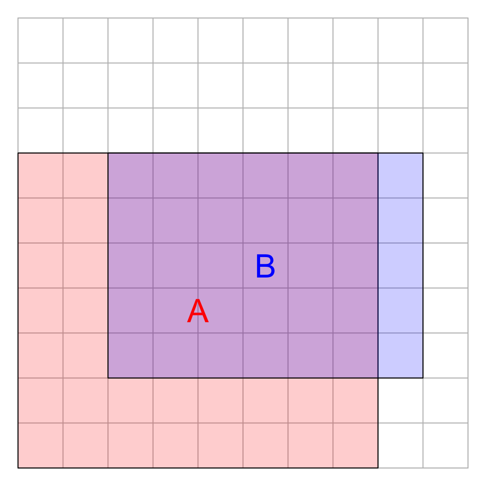

Let's call the red rectangle A and the blue rectangle B. Find the following areas:

- Area covered by A = squares
- Area covered by B = squares
- Area covered by the intersection of A and B = squares
- Area covered by the union of A and B = squares
- Area covered by ONLY A (and not B) = squares
- Area covered by ONLY B (and not A) = squares
- Area not covered (neither A nor B) = squares
- Area covered by A = 56
- Area covered by B = 35
- Area covered by the intersection of A and B = 30
- Area covered by the union of A and B = 61
- Area covered by ONLY A (and not B) = 26
- Area covered by ONLY B (and not A) = 5
- Area not covered (neither A nor B) = 39

Jason drew two overlapping rectangles on a 10x10 grid.

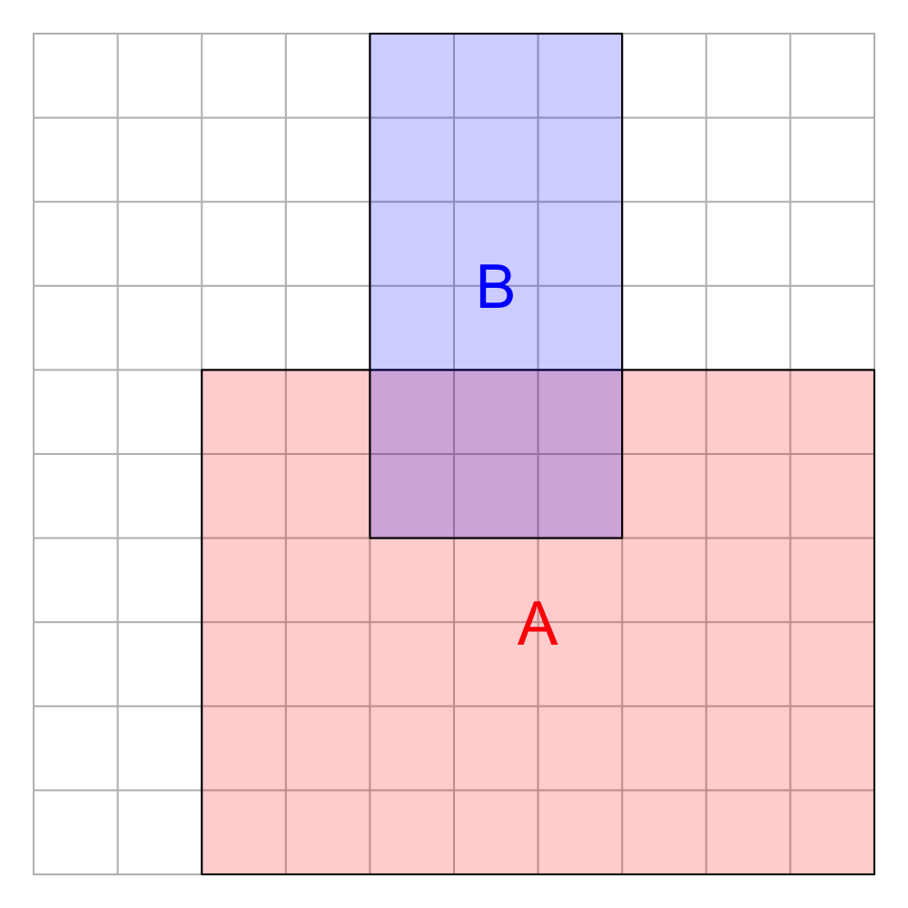

Let's call the red rectangle A and the blue rectangle B. Find the following areas:

- Area covered by A = squares
- Area covered by B = squares
- Area covered by the intersection of A and B = squares
- Area covered by the union of A and B = squares
- Area covered by ONLY A (and not B) = squares
- Area covered by ONLY B (and not A) = squares
- Area not covered (neither A nor B) = squares
- Area covered by A = 48
- Area covered by B = 18
- Area covered by the intersection of A and B = 6
- Area covered by the union of A and B = 60
- Area covered by ONLY A (and not B) = 42
- Area covered by ONLY B (and not A) = 12
- Area not covered (neither A nor B) = 40